# HMigD I App Tutorial. V1.0

### 3.1.3 Circular plots

[figure not shown]

The Circular Plots panel helps visualize single and aggregated flows in the form of circular flow plots for the selected model. The model selection can be done through a dropdown list, similar to the “Compare Single Flows” and “Compare Aggregated Flows” subpanels (see sections 3.1.1.1 and 3.1.2 respectively):

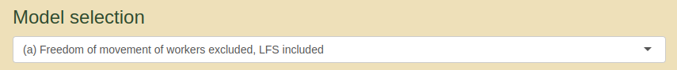

Similar to aggregated flows (section 3.1.2), users can select several receiving and sending countries.

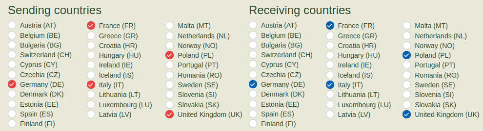

Fast selection of countries can be performed using the following buttons, as described in section 3.1.2.

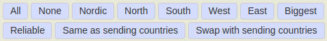

To change the year, use the “Year Slider” on the right side of the plot:

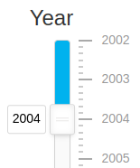

If you want to mask some flows, use the “Limit Visible Flows” slider next to the “Year” slider. The masking method uses the percentile method, so the higher the value on the slider, the more flows are masked.

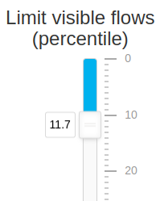

The plot can be saved in a chosen format using the bottom frame:

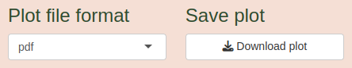

## 3.2 Model mixing & download Panel

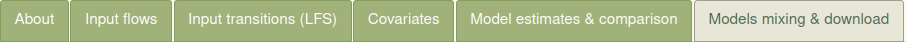

### 3.2.1 Fast download of estimated flows

[figure not shown]

### 3.2.2 Alternative model selection

[figure not shown]

Initially, the table displays the model recommended for specific flows, based on our informed arbitrary decisions.

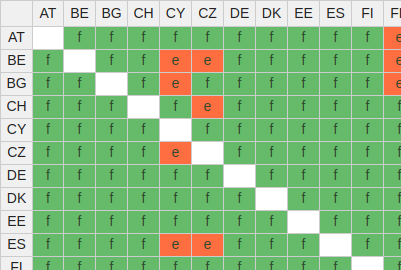

However, the user can change this selection by double-clicking on the specific field and selecting the appropriate model.

You can import and export your selection to/from your local storage as well as restore default settings using:

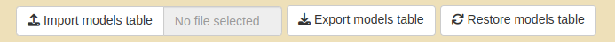

### 3.2.3 Visualiztion of the database

[figure not shown]

This panel shows a simple summary of the database using user model selection. The flows are classified according to a quasi-logarithmic scale, as shown in the legend:

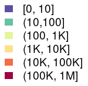

To navigate across years, use the “Year” slider:

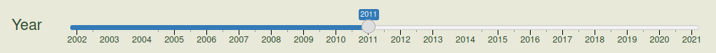

# 4 Remarks

Thank you for completing the tutorial. For any issues and questions, please contact Maciej Danko at danko@demogr.mpg.de.